# The NBA MVP Race: Eye-test or a tale of advanced stats?

Author

Seps Sepahvand

# Introduction

For the past 3 years, it seems like the the title of the best player in the league, cemented by receiving the *Most Valuable Player* (MVP) award, has felt unusually unsettled with no unanimous winner emerging. This is due to players such as Luka Doncic, Nikola Jokic, Shai Gilgeous-Alexander and Victor Wembanyama all having recording breaking seasons.

In the past, this award was given to the best player on the best team. However, recently it is a feat of “consistent individual excellence combined with team leadership” that will grant a player that title. But how can we measure these qualities? Fran Blinebury, an NBA MVP voter says “I know it when I see it”. Scott Howard-Cooper, another voter, states that its a mixture of statistics, personal eye test and personal judgement.[^1]

The explosion of advanced analytics has changed the way fans and analysts understand the game, offering deeper insight into a player’s value than ever before. Which leads to this important question:

Can these advanced metrics reveal patterns in how NBA MVP votes are awarded?

## Methodology

The value of each player and their expected MVP vote share is estimated using a number of different methods:

1. A linear regression which uses personal points, rebounds an assist numbers mixed with advanced stats such as Estimated Plus Minus (EPM), Field Goal percentage and Win Share.
2. A machine trained model using player performance data that takes past data to construct a regression with minimal RMSE.
3. Evaluation of player impact via contribution to team wins.

### Web Scraping

The information that is needed for this study is very much scattered. Therefore, four separate websites were used to gather information on all aspects of the game:

1. A TSN article: Published in October of last year ranking every team:

   This article illustrates the expectations of analysts at the start of the season. Subsequently, it could be used to identify teams that have exceeded expectations.
2. ESPN current power ranking: This website contains the projected seeds given a teams current record. We will need this dataset since the NBA season is not over yet.
3. NBA Awards Voting: Basketball Reference is a website that contains all NBA MVP votes for each player from the year 1955 to 2025.
4. DUNKS&THREES: This website calculates advanced stats such as EPM and Field Goal % for all NBA players.

# Player Comparison

Here are the MVP candidates and their stats this year:

| name | pts_per_g | ast_per_g | trb_per_g | fg_pct | ws | OFF | DEF | EPM |
| --- | --- | --- | --- | --- | --- | --- | --- | --- |
| Luka Doncic | 33.5 | 8.3 | 7.7 | 0.476 | 9.4 | 6.5 | 0.3 | 6.8 |
| Victor Wembanyama | 24.8 | 3.1 | 11.5 | 0.350 | 9.7 | 4.1 | 4.6 | 8.7 |
| Shai Gilgeous-Alexander | 31.1 | 6.6 | 4.3 | 0.553 | 15.4 | 7.3 | 2.0 | 9.3 |
| Nikola Jokić | 27.7 | 10.9 | 12.9 | 0.569 | 14.6 | 7.4 | 0.7 | 8.1 |

To better understand the data and to see just how close this MVP race really is, a radar chart offers a clear visual comparison of each player’s performance across key metrics this season.

[interactive chart not shown]

# Data Cleansing

- After Web scraping the TSN and the ESPN projection website, they are merged together so that we have beginning of the season and end of the season projection in the same `tibble`. Additionally, a new column `Unexpected_Wins` will be added that is the difference between expected wins at the beginning of the season and expected wins with the season coming to an end. This metric tells us which teams have exceeded expectations.
- For the Advanced stats, the information from DUNKS&THREES and MVP votes from Basketball Reference are pulled into separate tables and later merged together using player name and season as reference keys.

# Regression Model

## Dependent Variable

In this regression model, our dependent variable needs to reflect how many MVP votes a player received. While we could use the raw vote totals scraped from Basketball Reference, this approach is misleading because the number of available votes varies widely from season to season. For example, Stephen Curry earned 1,310 votes as a unanimous MVP in 2016, while Nikola Jokić won in 2022 with only 650 votes due to a much closer race.

To make voting outcomes comparable across seasons, we use the **share of MVP votes received** rather than the raw totals. This standardizes the dependent variable and allows us to analyze patterns in MVP voting more reliably.

## Independent Variables

### PRA: Points Rebounds Assists

The most visible impact of a player is their points, assists and rebounds. We plug these parameters one at a time and see the impact of the inclusions of each parameter on our linear regression:

```
# A tibble: 3 × 5
  model                                   output r.squared adj.r.squared p.value
  <chr>                                   <list>     <dbl>         <dbl>   <dbl>
1 vote_share~pts_per_g                    <lm>       0.311         0.303       0
2 vote_share~pts_per_g + ast_per_g        <lm>       0.34          0.324       0
3 vote_share~pts_per_g + ast_per_g + trb… <lm>       0.372         0.348       0
```

As we add more variables to the regression model, the R‑squared consistently increases, suggesting that these metrics help explain a player’s MVP vote share. Because points, rebounds, and assists often tell a more complete story when viewed together, analysts frequently combine them into a single metric: **PRA (Points + Rebounds + Assists)** which captures a player’s overall box‑score impact.[^2]

The importance of PRA becomes clear when examining the relationship between MVP votes and PRA from 2010 to 2025. Between 2010 and 2014, the player who led the league in PRA also finished with the **highest MVP vote share**, and players with elite PRA totals consistently landed in the top three of MVP voting. This demonstrates the importance of this metric and therefore, higher weight will be placed on this parameter in the regression.

[interactive chart not shown]

### Field Goal Percentage

When interpreting PRA, it’s important to remember that raw volume can be misleading. A player can inflate their PRA by taking a high number of shots, and jeopardize their team’s efficiency. That’s why PRA should be evaluated alongside a player’s field‑goal percentage.

High PRA paired with poor shooting often signals empty volume, while high PRA with strong efficiency reflects real offensive impact

Looking at the graph below, we can see that players like Dwyane Wade, John Wall, and Giannis may have similar PRA totals, but their efficiency (FG%) varies a lot. This shows that PRA alone is not a perfect parameter . For that reason, the regression model pairs PRA with field‑goal percentage to account for both volume and efficiency.

[interactive chart not shown]

There are also a few clear anomaly cases.  
In 2018, Russell Westbrook averaged 25 points, 10 rebounds, and 10 assists with respectable FG%, giving him the highest PRA among MVP candidates. Yet he still finished outside the top three in MVP voting. This shows that voters expect big scoring, rebounding, and assist numbers to **translate into wins**. High PRA and FG% helps, but without a strong team record, it isn’t enough to stay in the top tier of MVP consideration.

### Team Impact

Basketball Reference offers a valuable metric called **Win Share** that measures the amount of wins contributed by a player. This metric is then combined with two advanced stats:

1. **Estimated Plus-Minus (EPM)**

   Is a metric that estimates how much a player helps or hurts their team per 100 possessions,
2. **Defensive Estimated Plus Minus (D-EPM):**

   Defensive EPM is the *defensive half* of the Estimated Plus‑Minus metric. Where overall EPM measures total impact, D‑EPM isolates how much a player helps their team on defense per 100 possessions.

As regression parameters, Win Shares capture a player’s contribution to team wins, EPM measures overall impact on point differential per possession, and D‑EPM isolates how many fewer points a team allows with that player on the floor.

Plugging these parameters into a regression:

- The model explains *62%* of variance in MVP vote share.
- PRA and Win Share exhibit the largest t-values, indicating they are the most statistically significant predictors in the model.

| term | estimate | std.error | statistic | p.value |
| --- | --- | --- | --- | --- |
| (Intercept) | -1.151539073 | 0.165209551 | -6.9701725 | 9.466676e-10 |
| PRA | 0.015481285 | 0.002665954 | 5.8070345 | 1.350870e-07 |
| fg_pct | 0.666153346 | 0.344537669 | 1.9334703 | 5.685391e-02 |
| DEF | 0.023547498 | 0.020892287 | 1.1270904 | 2.632044e-01 |
| EPM | 0.007510396 | 0.009810250 | 0.7655662 | 4.462748e-01 |
| ws | 0.026010452 | 0.005403919 | 4.8132573 | 7.251556e-06 |

Because previously we saw the significant of PRA and Win share as predictive parameters and knowing that MVP voters historically favors elite players on top‑winning teams, we increase the influence of PRA and Win Shares and fit them with a third‑degree polynomial to capture the nonlinear way voters reward production and team success.

| term | estimate | std.error | statistic | p.value |
| --- | --- | --- | --- | --- |
| (Intercept) | -5.291597e-01 | 1.499753e-01 | -3.528312 | 7.089245e-04 |
| I(PRA^3) | 3.216834e-06 | 5.119623e-07 | 6.283341 | 1.824900e-08 |
| fg_pct | 5.929130e-01 | 3.283212e-01 | 1.805893 | 7.484300e-02 |
| DEF | 2.105985e-02 | 1.967546e-02 | 1.070361 | 2.878004e-01 |
| EPM | 1.142111e-02 | 8.847816e-03 | 1.290840 | 2.006215e-01 |
| I(ws^3) | 5.232542e-05 | 9.373678e-06 | 5.582165 | 3.412522e-07 |

The model achieves a similar R‑squared but yields more statistically significant coefficients, indicating that the third‑degree polynomial is the better fit.

We now move on to our second mode.

# Machine Trained Regression

For our second model, we will create a linear regression model with a training and testing split to evaluate how well the model generalizes unseen data.

Because this approach is optimized through the minimization of prediction error, it may fail to consider factors such as the importance of Win Shares or PRA in MVP voting. Consequently, this model is best when placed alongside our earlier regression, which explicitly incorporates those structural relationships.

## Splitting and Testing

The data was split into a 70% training and 30% testing portion using the `rsample` and `recipes` packages. The linear regression model is trained on the 70% portion subset and then evaluated on the remaining 30% to assess performance.

## Outputs

Below are the resulting regression outputs:

| term | estimate | std.error | statistic | p.value |
| --- | --- | --- | --- | --- |
| (Intercept) | 0.216452423 | 0.01622849 | 13.3378021 | 6.268182e-18 |
| pts_per_g | 0.065536779 | 0.02157318 | 3.0378821 | 3.813033e-03 |
| ast_per_g | 0.024154046 | 0.01743943 | 1.3850250 | 1.723186e-01 |
| trb_per_g | 0.056916633 | 0.02262997 | 2.5150996 | 1.522982e-02 |
| fg_pct | 0.002287631 | 0.02154178 | 0.1061951 | 9.158611e-01 |
| ws | 0.093458180 | 0.02067042 | 4.5213489 | 3.905144e-05 |
| OFF | -0.423089212 | 0.59067438 | -0.7162816 | 4.772175e-01 |
| DEF | -0.169808951 | 0.26505670 | -0.6406514 | 5.247341e-01 |
| EPM | 0.488045440 | 0.65173099 | 0.7488449 | 4.575305e-01 |

The regression results indicate that **Points per game** and **Win Shares** are the most statistically significant predictors in the model, as reflected by their low p‑values and relatively large t‑statistics. Additionally, points per game, win share and EPM have the largest coefficient positive magnitudes, meaning that they have a positive relationships with MVP vote share. However, its important to note that the absolute size of these coefficients are rather small; suggesting that their impact on vote share is not overwhelmingly large.

| .metric | .estimator | .estimate |
| --- | --- | --- |
| mae | standard | 0.1130313 |
| rmse | standard | 0.1391334 |
| rsq | standard | 0.6736344 |

# Regression Prediction

Now we can plug-in our MVP candidates’ stats into our two regression models.

## Polynomial Regression Prediction

According to our first model, which places greater weight on Win Shares and PRA, Nikola Jokić emerges as the projected MVP, with Shai Gilgeous‑Alexander finishing as the runner‑up.

| name | predicted_vote_share |
| --- | --- |
| Victor Wembanyama | 0.1191060 |
| Luka Doncic | 0.2706703 |
| Shai Gilgeous-Alexander | 0.3764922 |
| Nikola Jokić | 0.5176946 |

Jokić’s combination of points, rebounds, and assists, along with his high Win Share total, creates a sizable advantage that translates into the majority of predicted votes.

## Machine Trained Linear Model Prediction

Our second regression model leads to the same conclusion. Once again, Jokić ranks as the strongest candidate, supported by his consistently high values across points, rebounds, assists, field‑goal percentage, and Win Shares. Shai Gilgeous‑Alexander follows closely behind, reaffirming the stability of the prediction across both modeling approaches.

| .pred | name |
| --- | --- |
| 0.2578665 | Luka Doncic |
| 0.2831816 | Victor Wembanyama |
| 0.3887030 | Shai Gilgeous-Alexander |
| 0.4970695 | Nikola Jokić |

# Unexpected Wins

MVP is not solely about personal statistics. It’s a team‑dependent award in a team‑dependent sport, where an underdog narrative is often appreciated and can subtly influence MVP voting. This was evident in 2011, when Derrick Rose won the award for leading Chicago to the first seed despite entering the season as underdogs and without posting historically dominant individual numbers.

The TSN article paints a picture of the expectations going into the season. Oklahoma, Denver, Cleveland and the New York were projected to be the top 4 seeds. However, currently with one more week to go, Detroit, Boston and San Antonio are emerging as unexpected playoff contenders that have racked up more wins than expected.

Here `Current_seed` is the anticipated final seed for each team today and `Projected_seed` is the anticipated seed predicted in October 2025.

| NBA_Team | Current_seed | Projected_seed | Unexpected_Wins |
| --- | --- | --- | --- |
| Detroit Pistons | 1 | 12 | 11 |
| Oklahoma City Thunder | 1 | 1 | 0 |
| Boston Celtics | 2 | 15 | 13 |
| San Antonio Spurs | 2 | 16 | 14 |
| New York Knicks | 3.2 | 4 | 0.8 |
| Denver Nuggets | 3.6 | 2 | -1.6 |
| Cleveland Cavaliers | 3.8 | 3 | -0.8 |
| Los Angeles Lakers | 4 | 10 | 6 |
| Houston Rockets | 4.5 | 5 | 0.5 |
| Atlanta Hawks | 5.6 | 11 | 5.4 |

[output cut: 20 more lines]

This table highlights that among the league’s top teams, San Antonio has delivered the most unanticipated success. They emerge as a legitimate contender for the second seed, outperforming expectations more than any other team in this tier. The graph below visualizes just how far their unexpected surge separates them from the rest of the field:

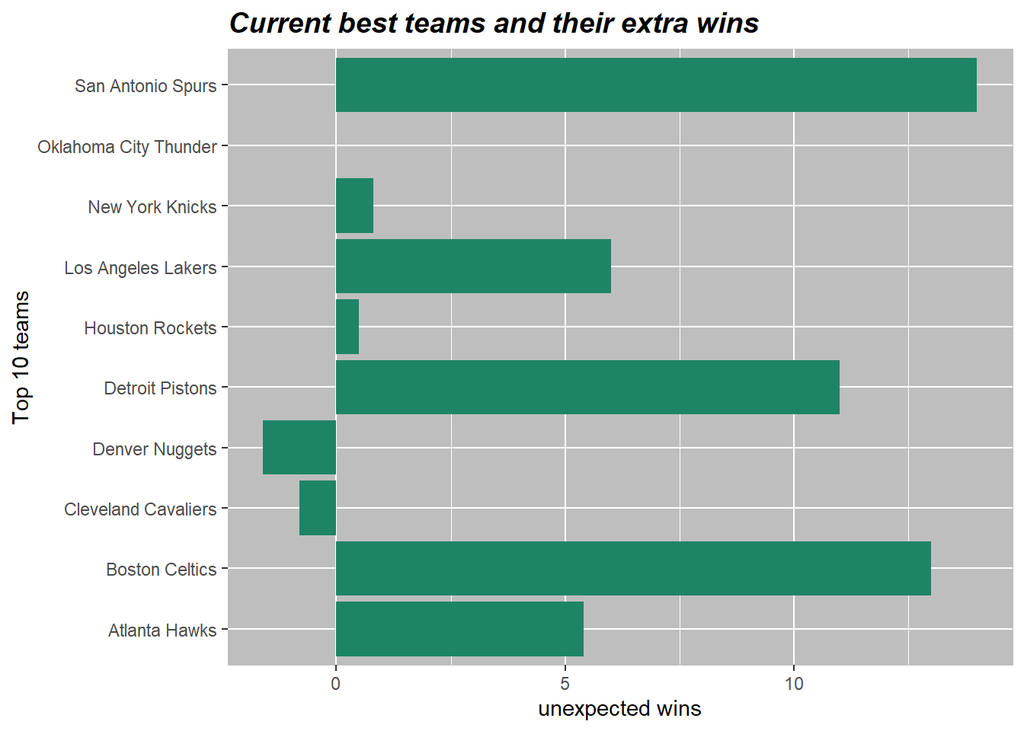

To understand San Antonio’s unexpected rise into title contention, we don’t have to look far. Victor Wembanyama has posted the **second‑highest overall EPM** in the league and **leads all players in Defensive EPM**. As noted earlier, these metrics correlate strongly with a player’s direct impact on winning often more reliably than raw scoring totals.

Consequently, even though the regression model still identifies Jokic as the projected MVP, **Wembanyama cannot be dismissed** as a legitimate contender.

# Conclusion

### Polynomial

In this study, the MVP race was examined from several analytical perspectives. the polynomial regression model that was built to reflect the historical behavior of MVP voters achieved a respectable **R² of 65%**. The model assigned strong significance to the influence of **PRA** and **Win Shares**, but due to the variance and noise inherent in the dataset, the predictive coefficients themselves remained relatively low.

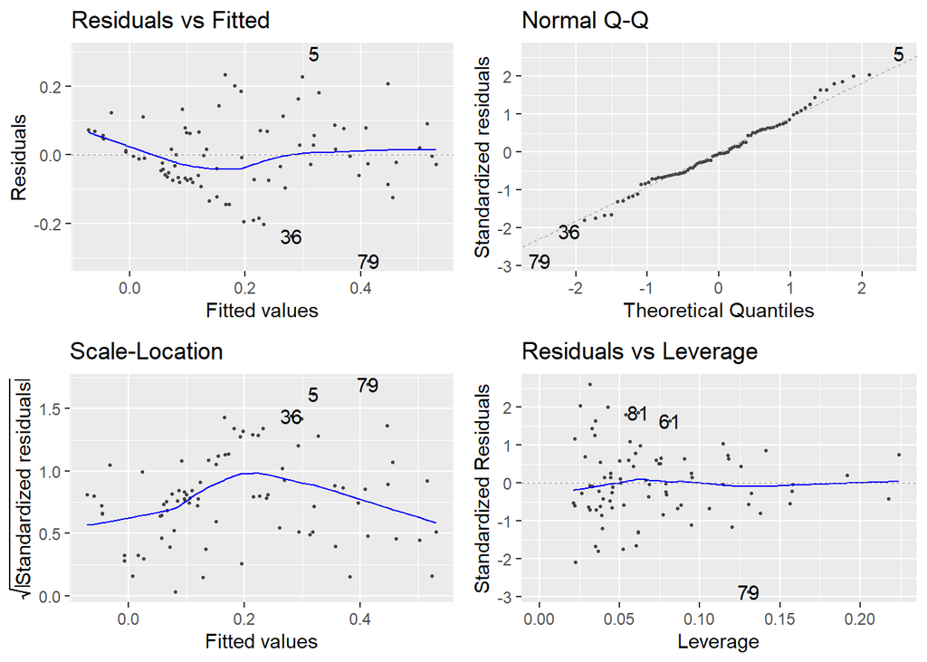

Looking at the relationship between the fitted values and the residuals, the residuals appear to average out to zero, and the Normal Q-Q plot suggests they are approximately normally distributed. However, the scale-location plot indicates that the variance is not consistent across the range of fitted values. This heteroskedasticity is a limitation that needs to be acknowledged when interpreting the model’s results.

### Machine-Trained Model

The machine‑trained model, which splits the data and performs internal training and validation, produced a slightly higher R². However, it suffers from the same underlying noise issues as the polynomial model, limiting its ability to generate sharply defined predictive weights.

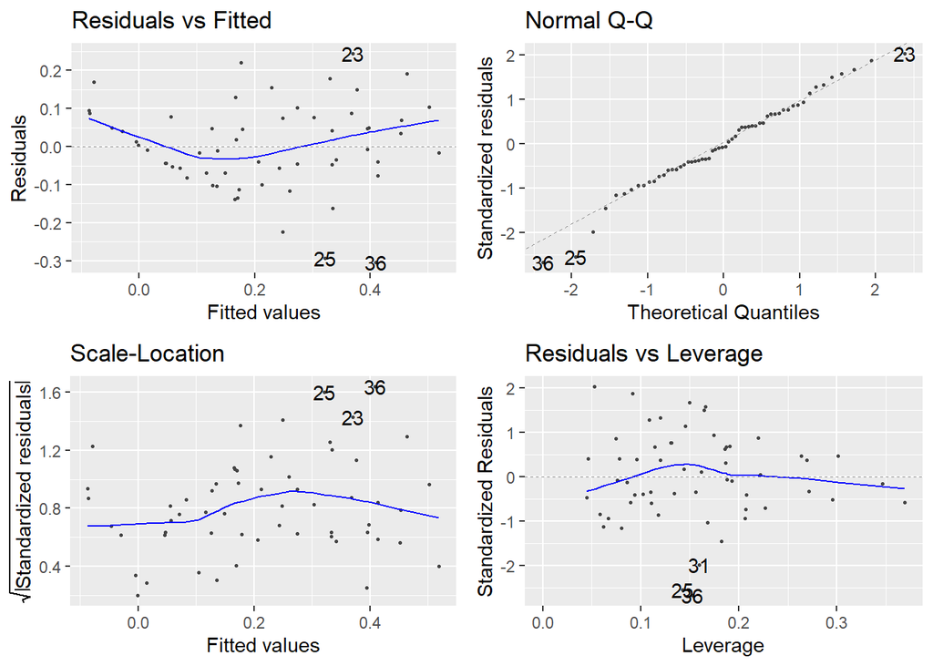

### MVP?

With all the limitations of our models in mind, both approaches ultimately predicted Nikola Jokić as the MVP and Shai Gilgeous‑Alexander as the runner‑up. However, it’s important to emphasize that Victor Wembanyama is in the middle of a genuine underdog narrative, leading a Spurs team that was not expected to contend into a legitimate playoff push. That storyline has historically mattered in MVP voting, and it adds a layer of uncertainty that pure statistical models can’t fully capture.

The real test for our model will come in **late May**, when the league officially announces the MVP and we can evaluate how well these predictions aligned with voter behavior.

## Footnotes

[^1]: https://www.nba.com/news/blogtable-what-criteria-matters-most-making-mvp-decision
[^2]: https://theballzone.com/whats-pra-in-nba/